# 1 Study area

```r
library(grassland)
theme_set(ggthemes::theme_few())
```

Download base maps. First, the study region boundary of the California Floristic Province (CFP).

```r
path_cfp <- down_cfp()
sf_cfp <- read_cfp(path_cfp = path_cfp)
```

```r
sf_cfp <- read_cfp(path_cfp = system.file("extdata", "cfp", package = "grassland"))
```

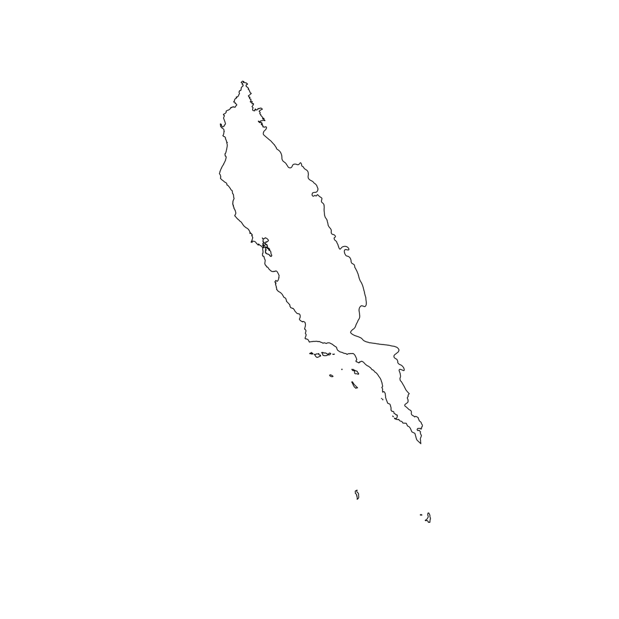

```r
sf_cfp %>% plot()
```

```r
path_grass <- down_grasscover(sf_cfp) # need Earthdata login credentials, slow
ras_grass <- read_grasscover(path_grass = path_grass)
```

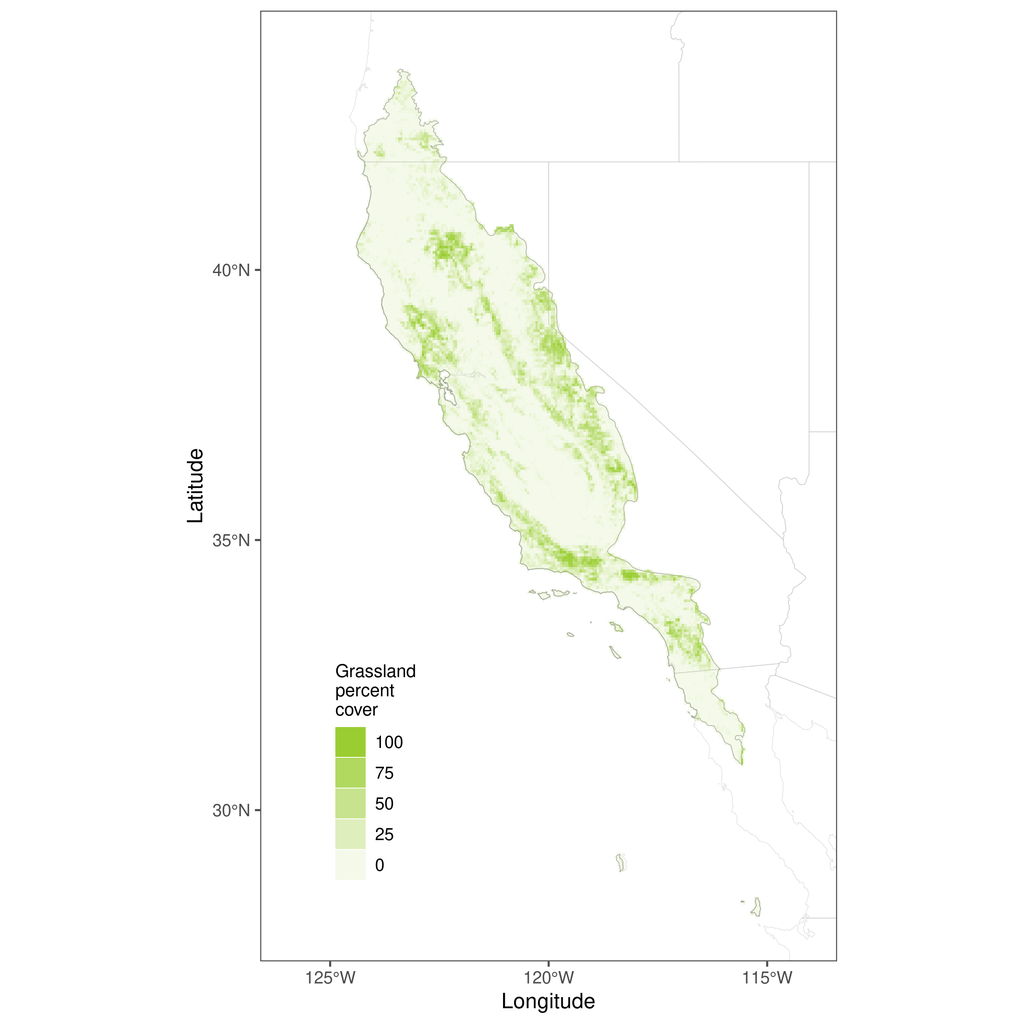

```r
ras_grass <- read_grasscover(path_grass = system.file("extdata", "cfp-grassland-percent-cover.tif", package = "grassland"))
gg_grass_map <- plot_site_map(sf_cfp = sf_cfp, ras_grass = ras_grass, plotsite = F)
gg_grass_map
```

```r
perc_grass <- summ_grass(ras_grass)
```

Download climate data from three sources: CHELSA, PRISM, and TerraClimate.

```r
path_clim <- down_climate()
dat_clim <- read_climate(path_clim = path_clim)
```

```r
dat_clim <- read_climate()
dat_clim
```

```
#> $chelsa
#> class       : SpatRaster
#> dimensions  : 20880, 43200, 12  (nrow, ncol, nlyr)
#> resolution  : 0.008333333, 0.008333333  (x, y)
#> extent      : -180.0001, 179.9999, -90.00014, 83.99986  (xmin, xmax, ymin, ymax)
#> coord. ref. : lon/lat WGS 84 (EPSG:4326)
#> sources     : bio1.tif
#>               bio12.tif
#>               vpd_max.tif
#>               ... and 9 more source(s)
#> names       : tmp, ppt, vpd, bio1, bio8, bio9, ...
#>
#> $prism
#> class       : SpatRaster
#> dimensions  : 3105, 7025, 3  (nrow, ncol, nlyr)
#> resolution  : 0.008333333, 0.008333333  (x, y)
#> extent      : -125.0208, -66.47917, 24.0625, 49.9375  (xmin, xmax, ymin, ymax)
#> coord. ref. : lon/lat NAD83
#> sources     : PRISM_tmean_30yr_normal_800mM4_annual_bil.bil
#>               PRISM_ppt_30yr_normal_800mM4_annual_bil.bil
#>               PRISM_vpdmax_30yr_normal_800mM4_annual_bil.bil
#> names       :      tmp,       ppt,   vpd
#> min values  : -11.5699,   45.5439,  1.99
#> max values  :  25.6899, 6210.9819, 54.37
#>
#> $terraclim
#> class       : SpatRaster
#> dimensions  : 4320, 8640, 4  (nrow, ncol, nlyr)
#> resolution  : 0.04166667, 0.04166667  (x, y)
#> extent      : -180, 180, -90, 90  (xmin, xmax, ymin, ymax)
#> coord. ref. : +proj=longlat +ellps=WGS84 +no_defs
#> sources     : tmp.tif
#>               ppt.tif
#>               vpd.tif
#>               ... and 1 more source(s)
#> names       :       tmp,     ppt,  vpd,    cwd
#> min values  : -53.24167,     0.0, 0.00,    0.0
#> max values  :  34.14167, 12390.2, 9.17, 3077.2
```

Summarize climate data in CFP.

```r
bbox_cfp <- summ_cfp_geography()
df_chelsa_cfp <- summ_cfp_climate(dat_clim, source = "chelsa")
```

CFP spans large geographic (115-124° W longitude, 28-44° N latitude) and climatic gradients (-8.35-20.3 °C temperature, 54.8-3600 mm precipitation).

Calculate climate change in CFP.

```r
path_climate_monthly <- down_climate_monthly()
path_climate_annual_cfp <- calc_climate_annual_cfp(indir = path_climate_monthly)
path_climate_change_cfp <- calc_climate_change_cfp(indir = path_climate_annual_cfp)
```

```r
df_cc_cfp <- summ_cfp_climate_change()


```

Historical climate observations show considerable warming (temperature increase by 0.026 °C yr<sup>-1</sup>) and drying (precipitation decrease by -5.45 mm yr<sup>-1</sup>) from 1980 to 2019.

From 1980 to 2019, the CFP had an overall warming trend of 0.026 ± 0.0000156 °C yr<sup>-1</sup> (mean ± std. err.), with 82.2% of the area having significant warming trends; the CFP had an overall drying trend of 5.45 ± 0.00804 mm yr<sup>-1</sup> with 21.4% of the area having significant drying trends.

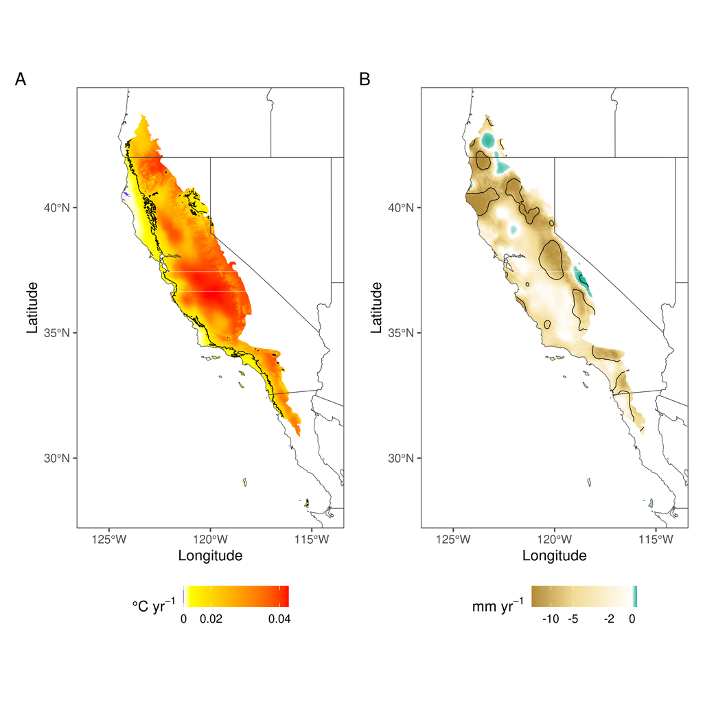

```r
gg_cfp_cc <- plot_climate_change_cfp()
gg_cfp_cc
```

Output figures and R data files.

```r
save_figure(out = list(
  grass_map = gg_grass_map,
  cfp_cc = gg_cfp_cc
))
save_extdata(out = list(path_cfp, path_grass))
```